# Data visualization in ggplot

### Dotplot

These same data could be displayed as a dotplot instead.

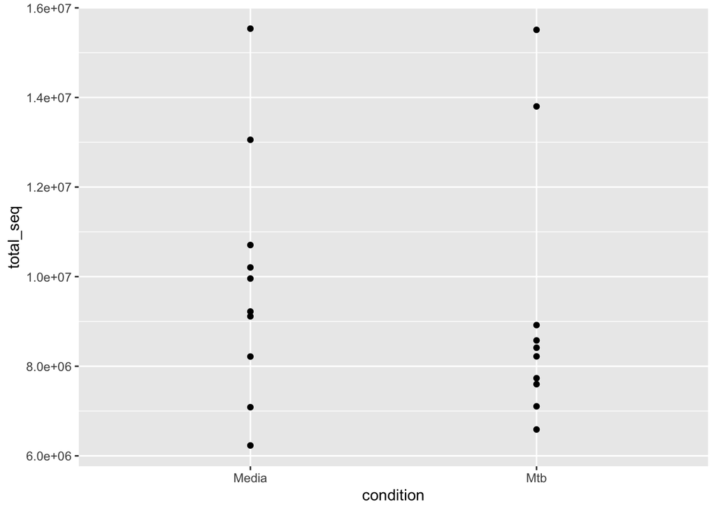

```r
ggplot(dat$targets) +
  aes(y = total_seq, x = condition) +
  geom_point() #<--- see change
```

And if we want to make sure we see every point, a jitter works nicely.

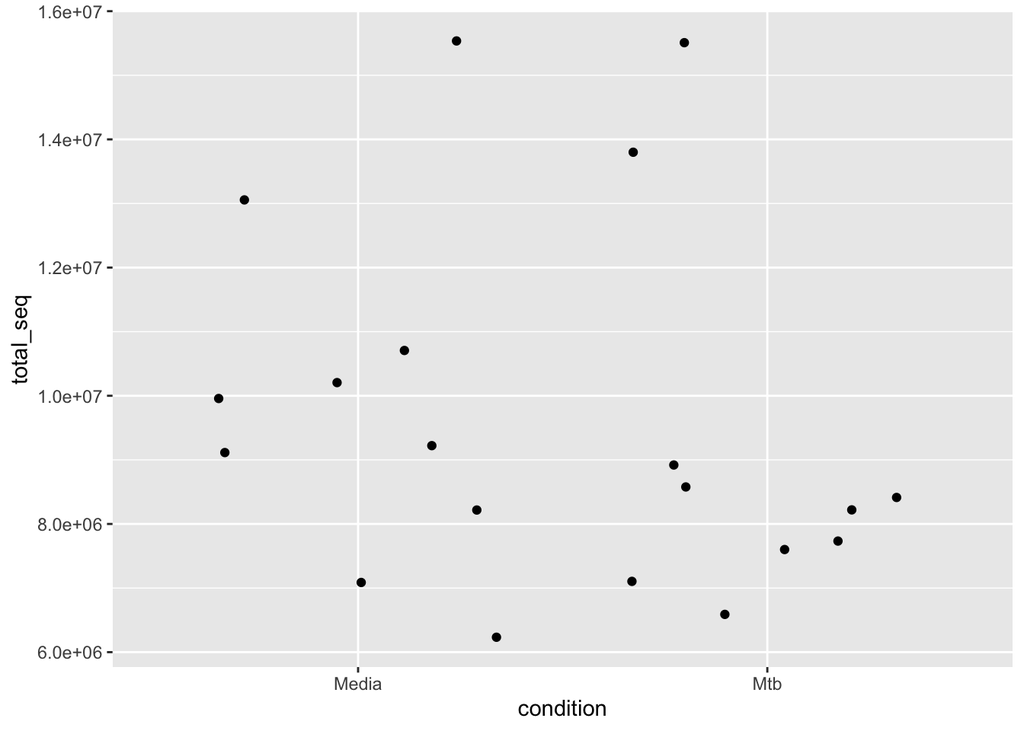

```r
ggplot(dat$targets) +
  aes(y = total_seq, x = condition) +
  geom_jitter() #<--- see change
```

### Multiple geoms

The building block nature of ggplot allows us to add multiple geoms on top of each other. So we can combine the two previous plots like so

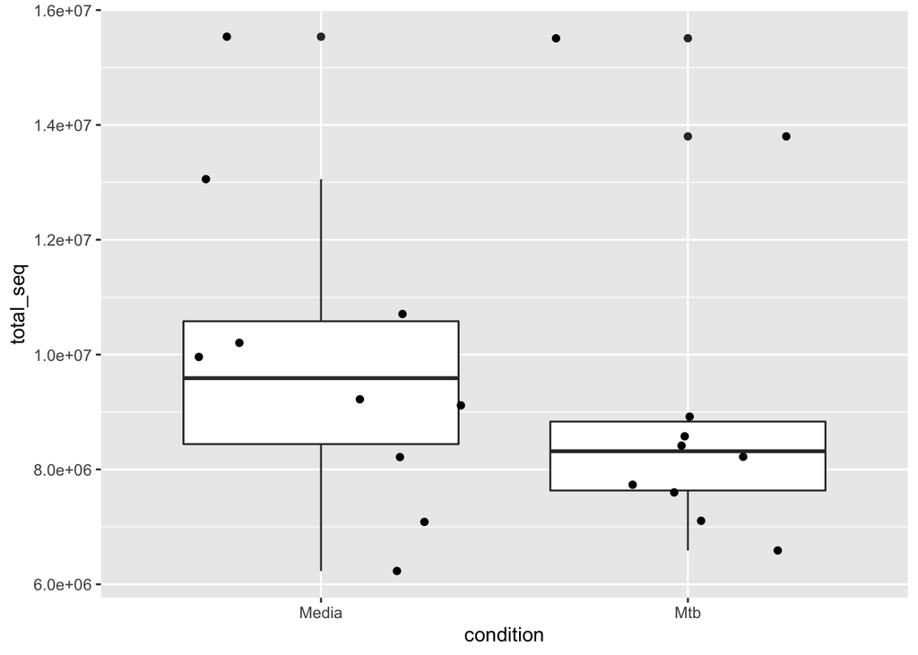

```r
ggplot(dat$targets) +
  aes(y = total_seq, x = condition) +
  geom_boxplot() + #<--- see change
  geom_jitter() #<--- see change
```

But you may notice that there are some duplicate points. Looking back at the first boxplots, there are points for points outside the box. These points remain in the above plot plus appear jittered from the second geom. We can fix this by telling the boxplot to not plot the outliers.

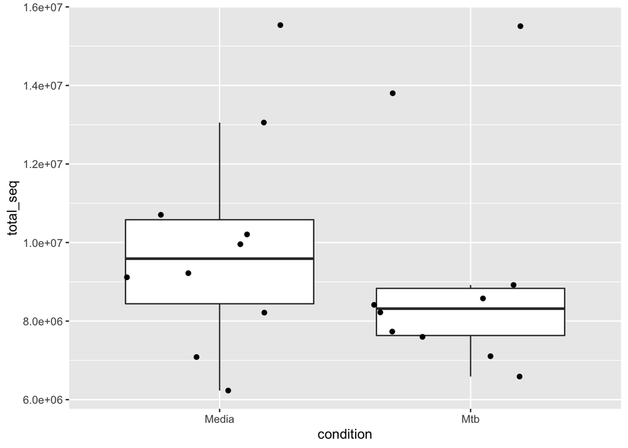

```r
ggplot(dat$targets) +
  aes(y = total_seq, x = condition) +
  geom_boxplot(outlier.shape = NA) + #<--- see change
  geom_jitter()
```

#### Order matters

Because ggplot works in layers, the order matters. If for example we put the boxplot after the jitter, the boxes cover up points! We use `alpha` for transparency so you can see these points. Thus, we careful when considering how you setup your plot!

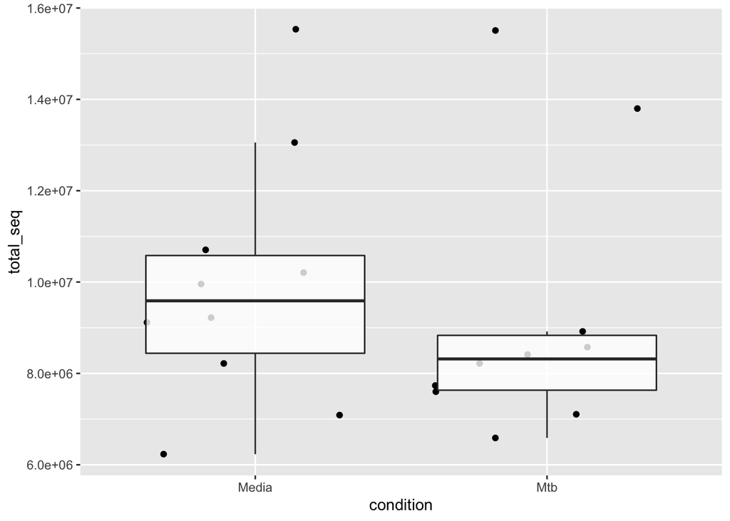

```r
ggplot(dat$targets) +
  aes(y = total_seq, x = condition) +
  geom_jitter() + #<--- see change
  geom_boxplot(outlier.shape = NA, alpha = 0.8)  #<--- see change
```

#### Why are my dots moving?

With jitter, you are adding random error to be able to see all the points. Because this is truly random, every time you run jitter, you will get a slightly different plot. To combat this, set a seed before making the plot.

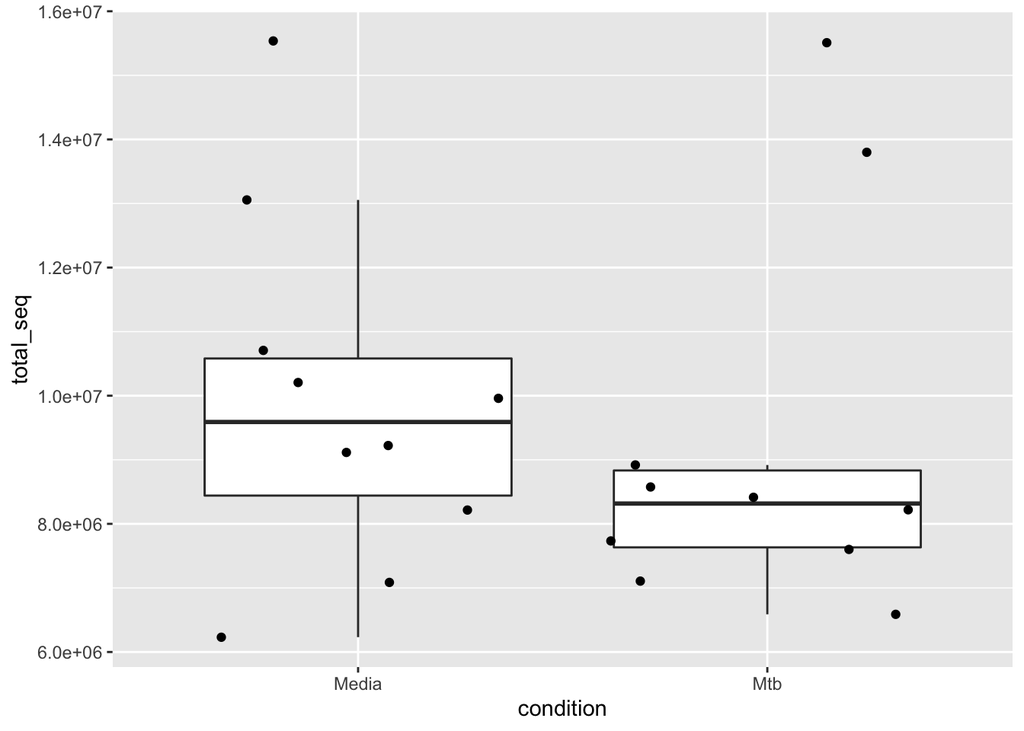

```r
set.seed(468) #<--- see change
ggplot(dat$targets) +
  aes(y = total_seq, x = condition) +
  geom_boxplot(outlier.shape = NA) +
  geom_jitter()
```

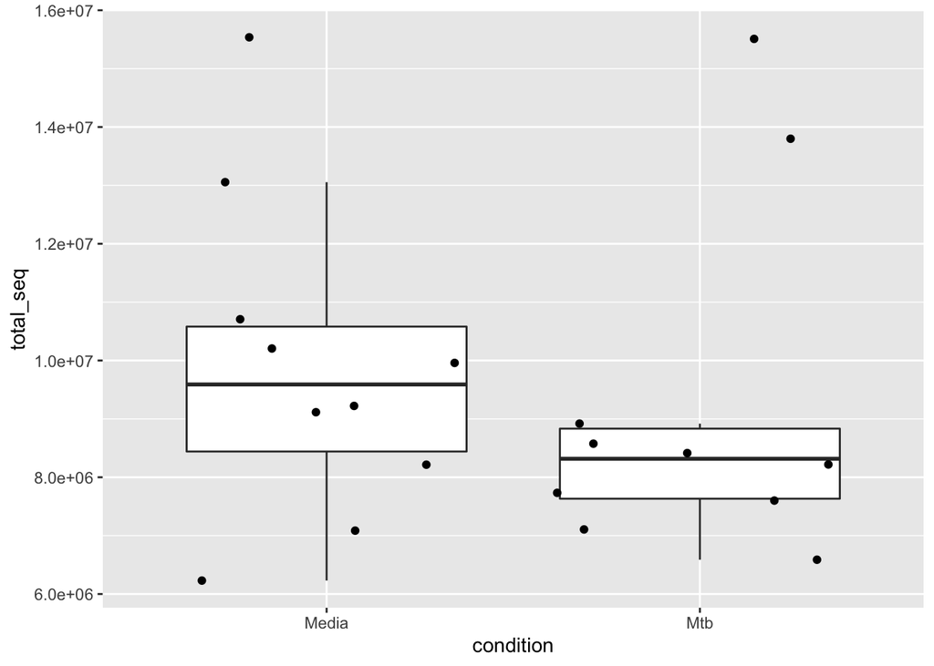

```r
set.seed(468) #<--- see change
ggplot(dat$targets) +
  aes(y = total_seq, x = condition) +
  geom_boxplot(outlier.shape = NA) +
  geom_jitter()
```

## RNA-seq plots

### PCA

One dotplot of interest in RNA-seq analysis is principle component analysis (PCA). In this plot, each RNA-seq library is a single point. The axes are unitless but in general, points that are closer together represent libraries with more similar gene expression. You can see large scale changes in gene expression in PCA. However, even when you don’t see clear PCA groupings, there can be significant differentially expressed genes. So don’t despair if your data don’t cluster in this plot!

Here, we calculate PCA from the normalized counts. Note that we transpose `t()` the counts data to get one PCA point per library, instead of one per gene.

```r
dat.pca <- prcomp(t(dat$E), scale.=TRUE, center=TRUE)

dat.pca$x[1:3,1:3]
```

```
##                   PC1       PC2      PC3
## pt01_Media -103.91401 -33.55704 22.40058
## pt01_Mtb     52.95006 -74.68146 24.78278
## pt02_Media  -60.61507  27.13460 24.58148
```

Then we use join to add metadata to the PCA data, so we can annotate the PCA plot.

```r
dat.pca.meta <- as.data.frame(dat.pca$x) %>%
  rownames_to_column("libID") %>%
  inner_join(dat$targets)
```

A nice trick with joins is to not specify what to join `by`. In this case, the function finds all columns shared between the data frames and uses them to match rows.

With `geom_point`, we have a PCA!

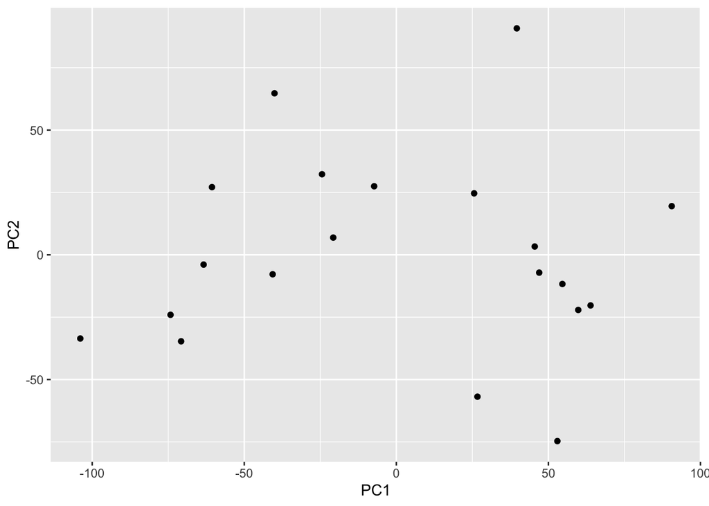

```r
ggplot(dat.pca.meta) +
  aes(x = PC1, y = PC2) +
  geom_point()
```

#### Color and shape

But it’s not very informative, so let’s annotate with our condition groups. In general, you want to use annotations in the following order: space, color, shape, size. These are ordered by how easily the human eye can discern differences.

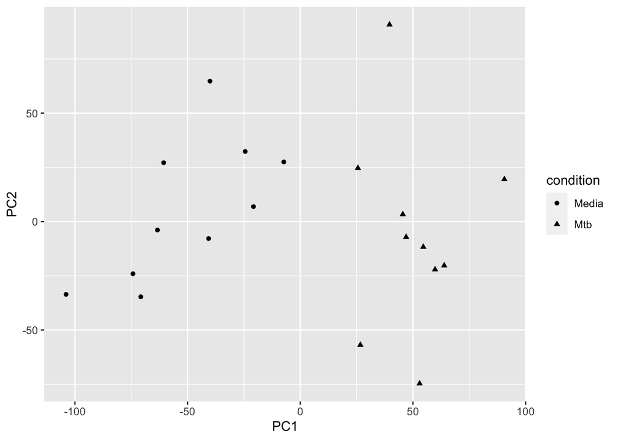

```r
ggplot(dat.pca.meta) +
  aes(x = PC1, y = PC2, shape = condition) + #<--- see change
  geom_point()
```

I like to keep all my aesthetics in one layer, but you could keep adding `aes()` functions to the plot if you prefer.

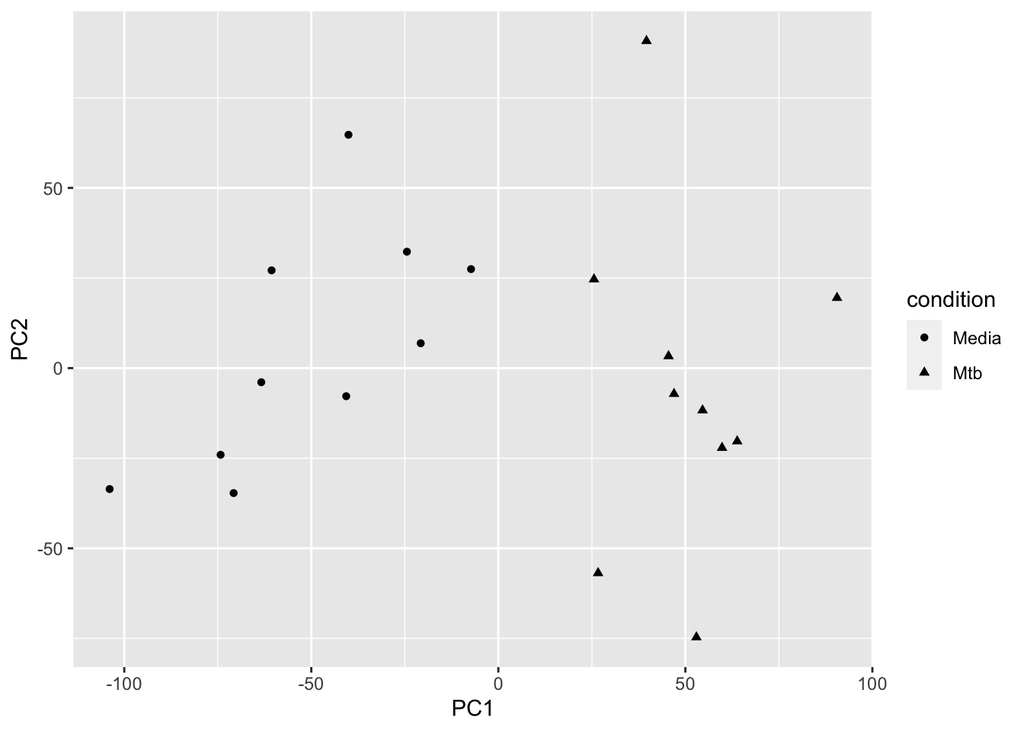

```r
ggplot(dat.pca.meta) +
  aes(x = PC1, y = PC2, shape = condition) + #<--- see change
  geom_point()
```

We’re not showing size or transparency because these aesthetics are difficult to see and should be avoided unless you *really* need them or the differences between data points are large.

#### Labels

We can also improve our axes and legend labels. First we see what proportion of variation is explained by each PC.

```r
summary(dat.pca)$importance
```

```
##                             PC1      PC2      PC3      PC4      PC5      PC6
## Standard deviation     57.21487 38.99933 35.32881 34.21306 29.76604 27.13699
## Proportion of Variance  0.24395  0.11334  0.09301  0.08723  0.06603  0.05488
## Cumulative Proportion   0.24395  0.35729  0.45030  0.53753  0.60356  0.65844
##                             PC7      PC8      PC9     PC10     PC11     PC12
## Standard deviation     24.48881 23.98672 21.83296 21.23941 19.84912 18.33097
## Proportion of Variance  0.04469  0.04288  0.03552  0.03362  0.02936  0.02504
## Cumulative Proportion   0.70313  0.74601  0.78153  0.81515  0.84451  0.86955
##                            PC13     PC14     PC15     PC16     PC17     PC18
## Standard deviation     18.05337 17.40958 17.13667 15.67883 14.48455 14.12701
## Proportion of Variance  0.02429  0.02259  0.02188  0.01832  0.01563  0.01487
## Cumulative Proportion   0.89384  0.91642  0.93831  0.95663  0.97226  0.98713
##                            PC19         PC20
## Standard deviation     13.14034 1.137607e-13
## Proportion of Variance  0.01287 0.000000e+00
## Cumulative Proportion   1.00000 1.000000e+00
```

And use that for labels as well as change the legend.

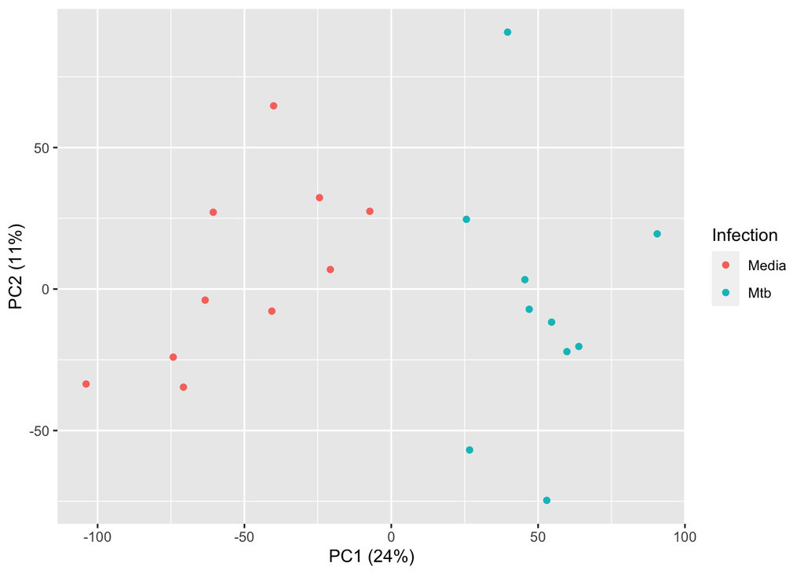

```r
ggplot(dat.pca.meta) +
  aes(x = PC1, y = PC2, color = condition) +
  geom_point() +
  labs(x = "PC1 (24%)", y = "PC2 (11%)", #<--- see change
       color = "Infection")
```

#### Themes

`ggplot` has a number of themes that change the aesthetics of the plot. I like `theme_classic` for PCA. You can also checkout more themes in the package `ggthemes`

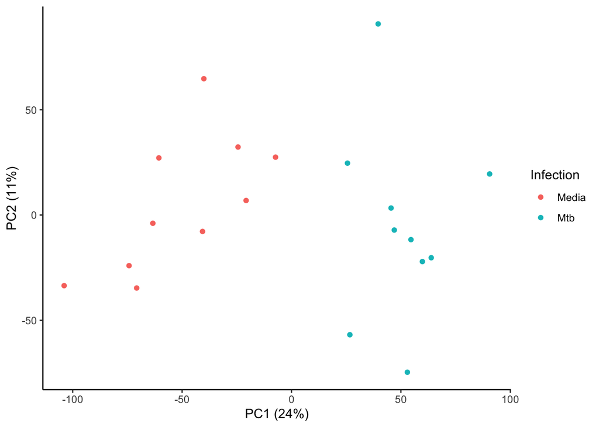

```r
ggplot(dat.pca.meta) +
  aes(x = PC1, y = PC2, color = condition) +
  geom_point() +
  labs(x = "PC1 (24%)", y = "PC2 (11%)",
       color = "Infection") +
  theme_classic() #<--- see change
```

### volcano plot

Let’s move on to another application of `geom_point`. A volcano plot shows differentially expressed gene significance and fold change.

#### Linear modeling

We’ll need to perform linear modeling to determine these results. Below is the workflow for comparing Mtb-infected vs media samples, corrected for sex and blocked by patient. We use our R package [`kimma`][https://github.com/BIGslu/kimma]. You DO NOT need to run these steps. They are here in case you want to run a similar analysis in the future.

```r
install.packages("devtools")
devtools::install_github("BIGslu/kimma")
```

```r
library(kimma)
```

```r
fit <- kmFit(dat, model = "~ condition + sex + (1|ptID)",
             run.lme = TRUE, use.weights = TRUE)
```

```
lme/lmerel model: expression~condition+sex+(1|ptID)
Input: 20 libraries from 10 unique patients
Model: 20 libraries
Complete: 13419 genes
Failed: 0 genes
```

```r
save(fit, file="data/kimma_result.RData")
```

Instead, load the results from the data downloaded for this workshop. Note that this is an S3 object similar to the `dat` object. In it, we have our log2 fold change `estimate` and significance `FDR` for each gene and each variable.

```r
load("data/kimma_result.RData")

fit$lme
```

```
## # A tibble: 40,257 × 7
##    model gene   variable   estimate       pval      FDR gene_biotype
##    <chr> <chr>  <chr>         <dbl>      <dbl>    <dbl> <chr>
##  1 lme   A1BG   condition   -0.313  0.264      0.347    protein_coding
##  2 lme   A1BG   sex          0.0796 0.814      0.954    protein_coding
##  3 lme   A1BG   (1 | ptID)   0      1          1        protein_coding
##  4 lme   A2M    condition   -0.0940 0.605      0.682    protein_coding
##  5 lme   A2M    sex          1.40   0.0140     0.158    protein_coding
##  6 lme   A2M    (1 | ptID)   7.79   0.00525    0.0574   protein_coding
##  7 lme   A2ML1  condition    0.791  0.0191     0.0356   protein_coding
##  8 lme   A2ML1  sex         -2.53   0.00000156 0.000388 protein_coding
##  9 lme   A2ML1  (1 | ptID)   1.39   0.239      0.498    protein_coding
## 10 lme   A4GALT condition    2.66   0.0000318  0.000108 protein_coding
## # … with 40,247 more rows
```

#### Color

Let’s start with a basic dotplot like before. We first filter the fit data to just the variable condition so that we have 1 point per gene. Notice how we now pipe `%>%` the data into ggplot so that we can modify it in dplyr/tidyr first.

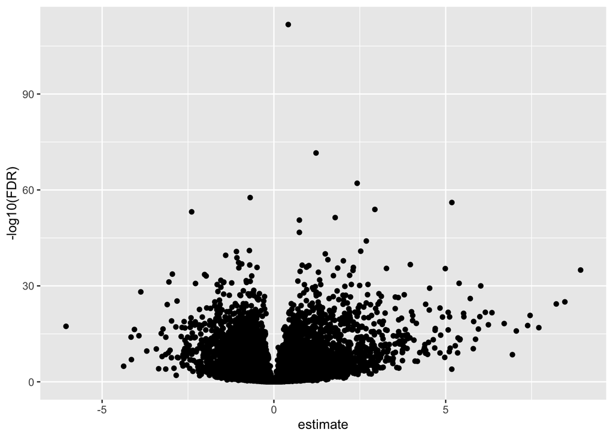

```r
fit$lme %>%
  filter(variable == "condition") %>%

  ggplot() +
  aes(x = estimate, y = -log10(FDR)) +
  geom_point()
```

Now let’s color the significant points. There is no “significant” variable in the data frame, so we first make one with mutate.

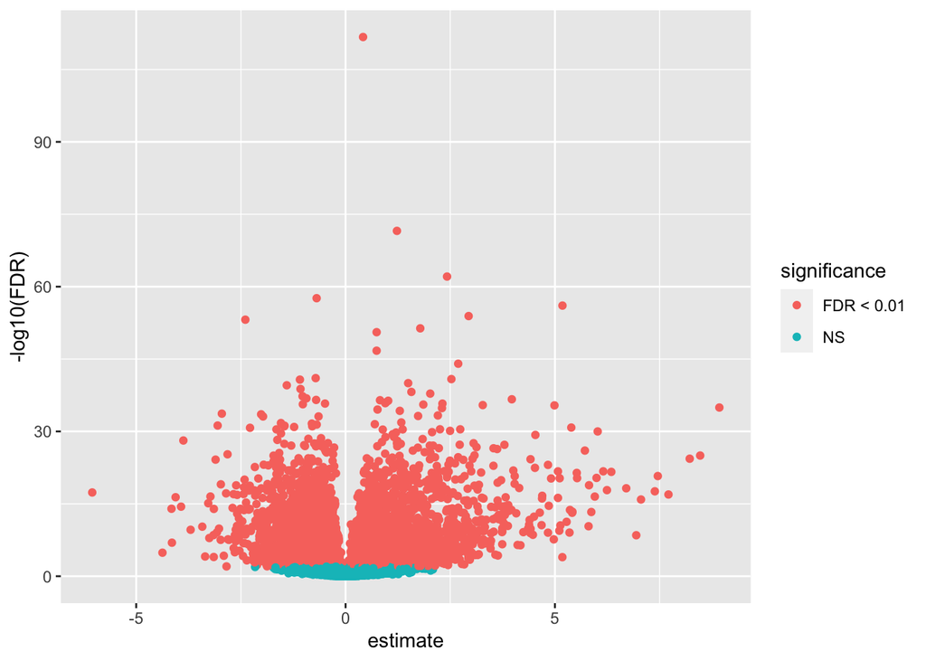

```r
fit$lme %>%
  filter(variable == "condition") %>%
  mutate(significance = case_when(FDR < 0.01 ~ "FDR < 0.01", #<--- see change
                                  TRUE ~ "NS")) %>%

  ggplot() +
  aes(x = estimate, y = -log10(FDR), color = significance) + #<--- see change
  geom_point()
```

Or go further and color up vs down regulated genes differently.

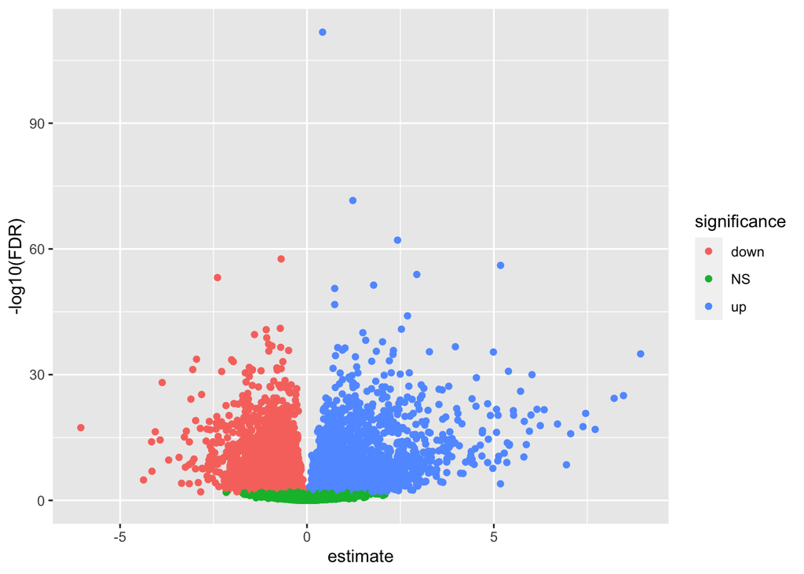

```r
fit$lme %>%
  filter(variable == "condition") %>%
  mutate(significance = case_when(FDR < 0.01 & estimate < 0 ~ "down", #<--- see change
                                  FDR < 0.01 & estimate > 0 ~ "up",
                                  TRUE ~ "NS")) %>%

  ggplot() +
  aes(x = estimate, y = -log10(FDR), color = significance) +
  geom_point()
```

And we can specify the colors we want with another layer.

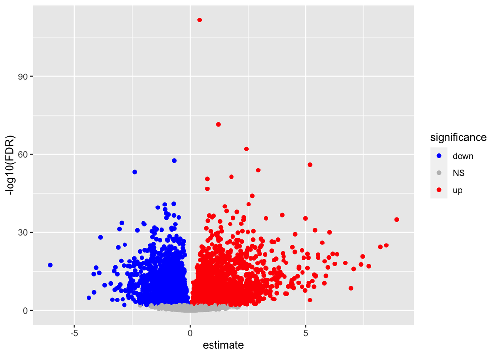

```r
fit$lme %>%
  filter(variable == "condition") %>%
  mutate(significance = case_when(FDR < 0.01 & estimate < 0 ~ "down",
                                  FDR < 0.01 & estimate > 0 ~ "up",
                                  TRUE ~ "NS")) %>%

  ggplot() +
  aes(x = estimate, y = -log10(FDR), color = significance) +
  geom_point() +
  scale_color_manual(values = c("blue", "grey", "red")) #<--- see change
```

#### Lines

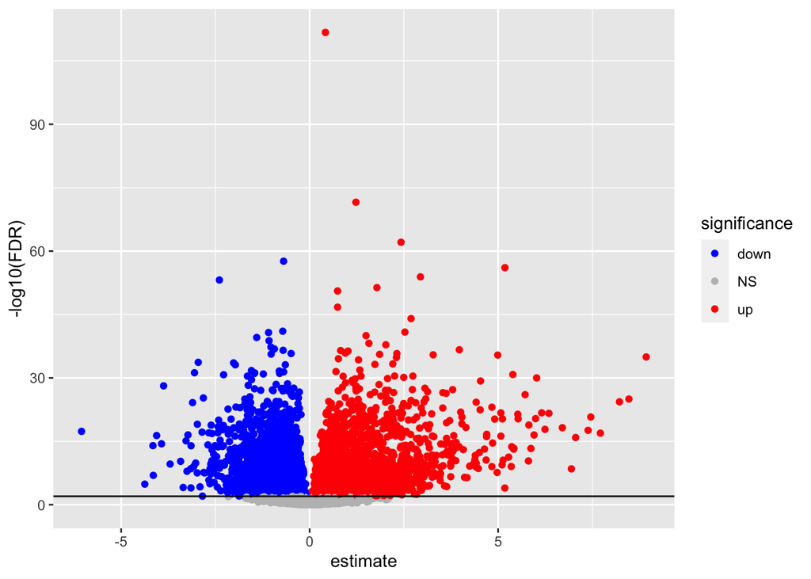

```r
fit$lme %>%
  filter(variable == "condition") %>%
  mutate(significance = case_when(FDR < 0.01 & estimate < 0 ~ "down",
                                  FDR < 0.01 & estimate > 0 ~ "up",
                                  TRUE ~ "NS")) %>%

  ggplot() +
  aes(x = estimate, y = -log10(FDR), color = significance) +
  geom_point() +
  scale_color_manual(values = c("blue", "grey", "red")) +
  geom_hline(yintercept = -log10(0.01)) #<--- see change
```

#### Scales

You might also wish to center the 0 estimate or otherwise alter the plots limits.

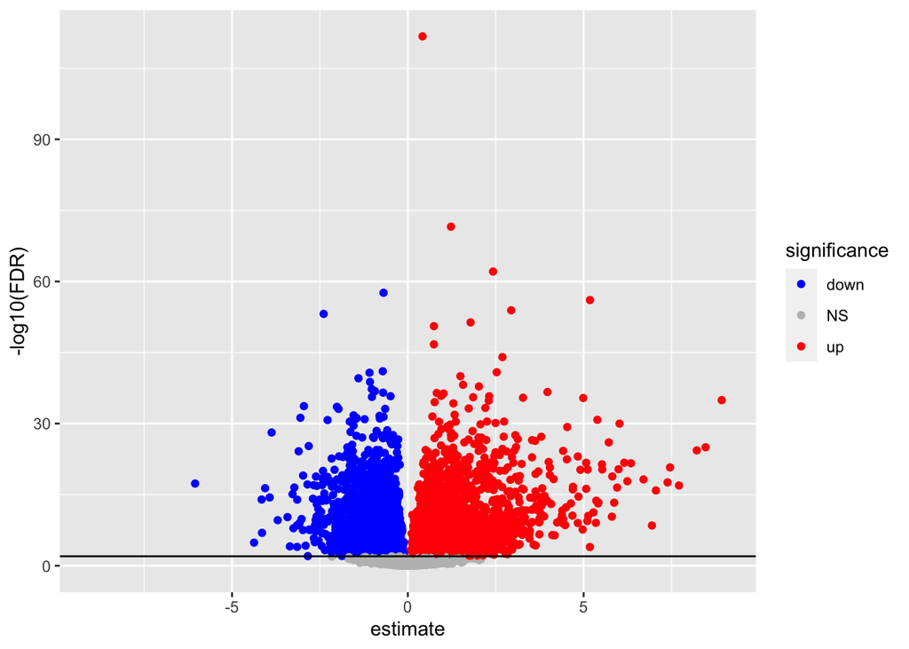

```r
fit$lme %>%
  filter(variable == "condition") %>%
  mutate(significance = case_when(FDR < 0.01 & estimate < 0 ~ "down",
                                  FDR < 0.01 & estimate > 0 ~ "up",
                                  TRUE ~ "NS")) %>%

  ggplot() +
  aes(x = estimate, y = -log10(FDR), color = significance) +
  geom_point() +
  scale_color_manual(values = c("blue", "grey", "red")) +
  geom_hline(yintercept = -log10(0.01)) +
  lims(x = c(-9, 9)) #<--- see change
```

If you accidentally (or purposefully) remove data point with your limits, R will warn you!

```
## Warning: Removed 14 rows containing missing values (geom_point).
```

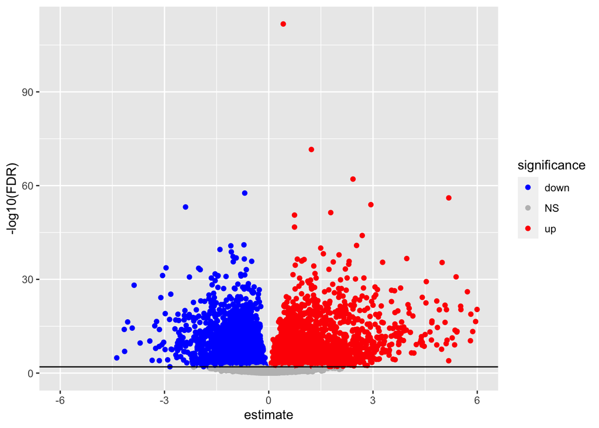

```r
fit$lme %>%
  filter(variable == "condition") %>%
  mutate(significance = case_when(FDR < 0.01 & estimate < 0 ~ "down",
                                  FDR < 0.01 & estimate > 0 ~ "up",
                                  TRUE ~ "NS")) %>%

  ggplot() +
  aes(x = estimate, y = -log10(FDR), color = significance) +
  geom_point() +
  scale_color_manual(values = c("blue", "grey", "red")) +
  geom_hline(yintercept = -log10(0.01)) +
  lims(x = c(-6, 6)) #<--- see change
```

#### Label points

We’re going to use a ggplot extension package to label our most significant genes. Please install and load it like so.

```r
install.packages("ggrepel")
```

```r
library(ggrepel)
```

First, we determine what our top 2 up and down regulated genes are.

```r
top_deg <- fit$lme %>%
  filter(variable == "condition") %>%
  mutate(direction = case_when(estimate < 0 ~ "down",
                               estimate > 0 ~ "up")) %>%
  group_by(direction) %>%
  slice_min(FDR, n=2) %>%
  pull(gene)

top_deg
```

```
## [1] "IFNAR2"  "NAIP"    "TERF2IP" "ZBTB21"
```

Then we add those labels to our fit data and use that variable in `geom_text_repel`

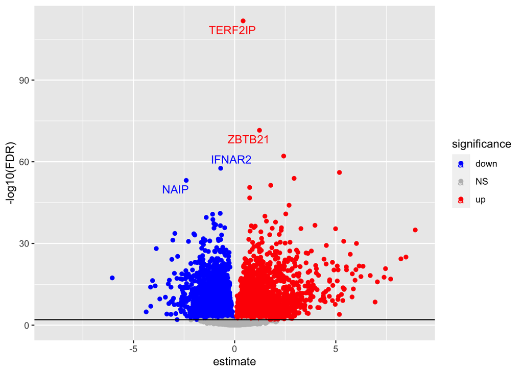

```r
fit$lme %>%
  filter(variable == "condition") %>%
  mutate(significance = case_when(FDR < 0.01 & estimate < 0 ~ "down",
                                  FDR < 0.01 & estimate > 0 ~ "up",
                                  TRUE ~ "NS")) %>%
  mutate(label = case_when(gene %in% top_deg ~ gene)) %>%

  ggplot() +
  aes(x = estimate, y = -log10(FDR), color = significance) +
  geom_point() +
  scale_color_manual(values = c("blue", "grey", "red")) +
  geom_hline(yintercept = -log10(0.01)) +
  lims(x = c(-9, 9)) +
  geom_text_repel(aes(label = label)) #<--- see change
```

And a small edit if you don’t want the text to be colored. When you put an aesthetic in a specific geom, it only applies that change to that one geom.

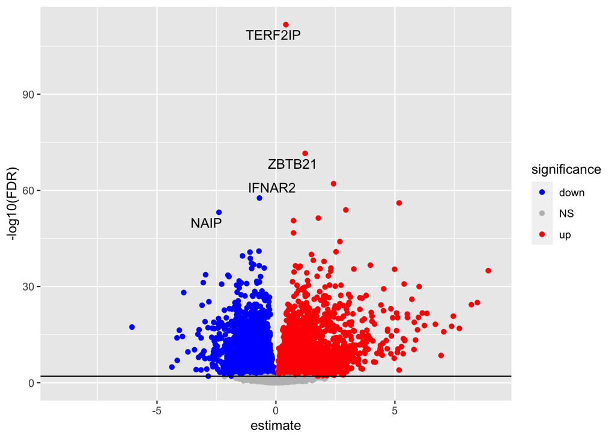

```r
fit$lme %>%
  filter(variable == "condition") %>%
  mutate(significance = case_when(FDR < 0.01 & estimate < 0 ~ "down",
                                  FDR < 0.01 & estimate > 0 ~ "up",
                                  TRUE ~ "NS")) %>%
  mutate(label = case_when(gene %in% top_deg ~ gene)) %>%

  ggplot() +
  aes(x = estimate, y = -log10(FDR)) + #<--- see change
  geom_point(aes(color = significance)) + # <--- see change
  scale_color_manual(values = c("blue", "grey", "red")) +
  geom_hline(yintercept = -log10(0.01)) +
  lims(x = c(-9, 9)) +
  geom_text_repel(aes(label = label))
```

#### Theme

To round it out, let’s look at `theme_bw`, my favorite one for volcano plots.

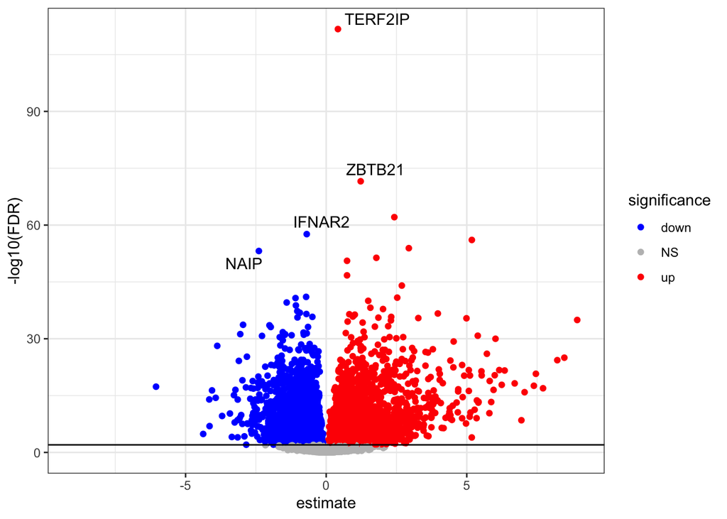

```r
fit$lme %>%
  filter(variable == "condition") %>%
  mutate(significance = case_when(FDR < 0.01 & estimate < 0 ~ "down",
                                  FDR < 0.01 & estimate > 0 ~ "up",
                                  TRUE ~ "NS")) %>%
  mutate(label = case_when(gene %in% top_deg ~ gene)) %>%

  ggplot() +
  aes(x = estimate, y = -log10(FDR)) +
  geom_point(aes(color = significance)) +
  scale_color_manual(values = c("blue", "grey", "red")) +
  geom_hline(yintercept = -log10(0.01)) +
  lims(x = c(-9, 9)) +
  geom_text_repel(aes(label = label)) +
  theme_bw() #<--- see change
```

There you have it! Did you think you’d reach a 12 function plot so soon?

#### Facets

With big data, we often want to plot more than one thing at once. Facets allow you to make similar plots across multiple subsets of data with only 1 additional line of code. Here, we don’t filter for just the condition variable and instead, facet across 2 of the variables in the model.

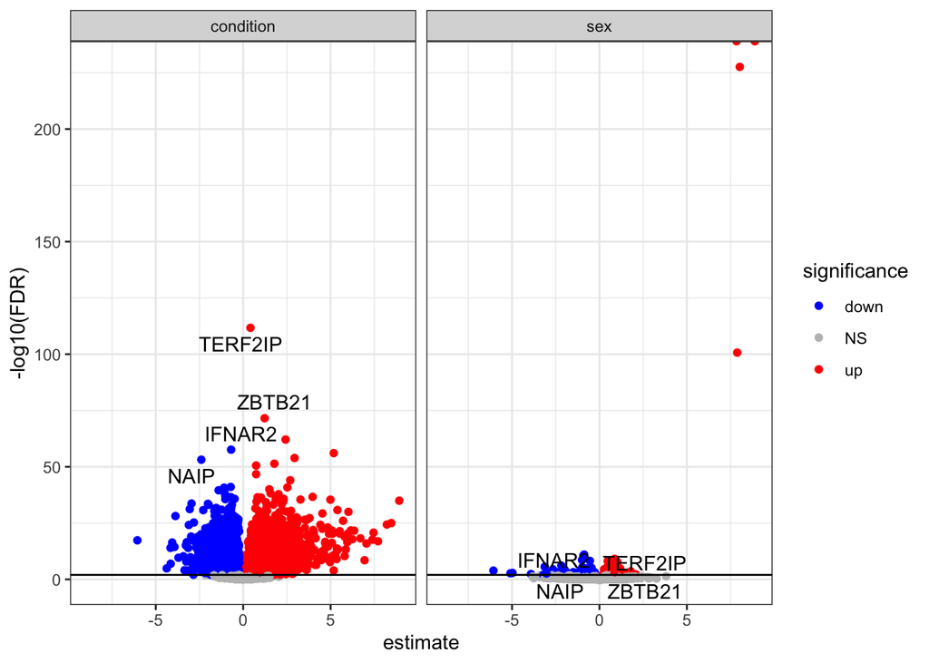

```r
fit$lme %>%
  filter(variable %in% c("condition", "sex")) %>% #<--- see change
  mutate(significance = case_when(FDR < 0.01 & estimate < 0 ~ "down",
                                  FDR < 0.01 & estimate > 0 ~ "up",
                                  TRUE ~ "NS")) %>%
  mutate(label = case_when(gene %in% top_deg ~ gene)) %>%

  ggplot() +
  aes(x = estimate, y = -log10(FDR)) +
  geom_point(aes(color = significance)) +
  scale_color_manual(values = c("blue", "grey", "red")) +
  geom_hline(yintercept = -log10(0.01)) +
  lims(x = c(-9, 9)) +
  geom_text_repel(aes(label = label)) +
  theme_bw() +
  facet_wrap(~ variable) #<--- see change
```

Since the y scales differ substantially for the two variable, we allow them to differ with `scales`. This can be set to “free_x”, “free_y”, or “free” for both x and y.

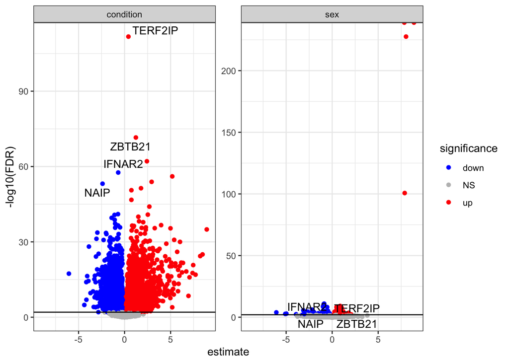

```r
fit$lme %>%
  filter(variable %in% c("condition", "sex")) %>% #<--- see change
  mutate(significance = case_when(FDR < 0.01 & estimate < 0 ~ "down",
                                  FDR < 0.01 & estimate > 0 ~ "up",
                                  TRUE ~ "NS")) %>%
  mutate(label = case_when(gene %in% top_deg ~ gene)) %>%

  ggplot() +
  aes(x = estimate, y = -log10(FDR)) +
  geom_point(aes(color = significance)) +
  scale_color_manual(values = c("blue", "grey", "red")) +
  geom_hline(yintercept = -log10(0.01)) +
  lims(x = c(-9, 9)) +
  geom_text_repel(aes(label = label)) +
  theme_bw() +
  facet_wrap(~ variable, scales = "free_y") #<--- see change
```

# Exercises: ggplot

1. Using the combined expression and metadata you made in the last session, plot the expression of one gene in media vs Mtb. The plot type is up to you! As a reminder, here is how we made the combined data.

```r
full_data <- as.data.frame(dat$E) %>%
  rownames_to_column("gene") %>%
  pivot_longer(-gene, names_to = "libID", values_to = "log2CPM") %>%
  inner_join(dat$targets)
```

2. Color the PCA by the numeric variable `total_seq`. Explore the help pages for `scale_color_continuous`, `scale_color_gradient`, or `scale_color_gradient2` and recolor your PCA to more easily see differences. As a reminder, here is the base PCA plot.

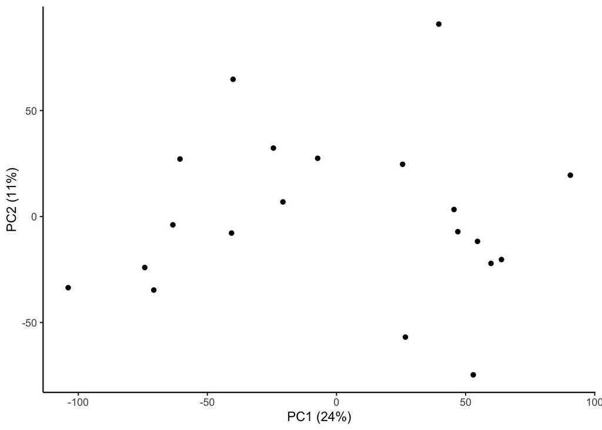

```r
ggplot(dat.pca.meta) +
  aes(x = PC1, y = PC2) +
  geom_point() +
  labs(x = "PC1 (24%)", y = "PC2 (11%)",
       color = "Infection") +
  theme_classic()
```

3. Using `geom_text_repel`, label the points in the PCA by their `libID`

# *Navigation*

- [Workshop index](https://bigslu.github.io/workshops/2022.08.15_R.tidyverse.workshop/index.html)
- Previous lesson: [Data visualization in ggplot](https://bigslu.github.io/workshops/2022.08.15_R.tidyverse.workshop/3_ggplot.html)
- [Lesson source code](https://github.com/BIGslu/workshops/blob/main/2022.08.15_R.tidyverse.workshop/3_ggplot.Rmd)